# Inversión pública en infraestructura educativa y su relación con la densidad poblacional (sin outliers)

2025-05-14

# PREPARAMOS LA DATA

**Autor:** Carlos Mansilla

## DATA: MONTO DE INVERSIONES

Importamos la base de datos que se trabajó:

```r
library(rio)
data = import("datos_categorizados3.xlsx")
```

Quitamos los valores irrelevantes que se catalogaron de manera manual:

```r
data <- data[data$CATEGORIA_INV != "NO RELEVANTE", ]
data <- data[data$CATEGORIA_INV != "NO RELACIONADO", ]
```

Para realizar las pruebas, preparo la fecha para realizar el filtrado adecuado:

```r
data$FECHA_REGISTRO <- substr(data$FECHA_REGISTRO, 1, 4)
```

Aquí filtro el año (2021) porque es el censo de población que he encontrado. Actualmente no encontré de otros años (solo algunas estimaciones):

```r
library(dplyr)
data_filtrada <- data %>%
  filter(FECHA_REGISTRO >= 2021)
```

Es muy probable que los resultados sean sesgados por outliers (inversiones públicas muy altas). Por lo que procederé a filtrar calculando los cuartiles e IQR. Eliminaré esos outliers para practicidad de la presente revisión:

```r
Q1 <- quantile(data_filtrada$COSTO_ACTUALIZADO, 0.25, na.rm = TRUE)
Q3 <- quantile(data_filtrada$COSTO_ACTUALIZADO, 0.75, na.rm = TRUE)
IQR_val <- Q3 - Q1

#Definir límites (método estándar: 1.5 * IQR)
lim_inf <- Q1 - 1.5 * IQR_val
lim_sup <- Q3 + 1.5 * IQR_val

# Filtrar datos sin valores atípicos
data_filtrada <- data_filtrada %>%
  filter(COSTO_ACTUALIZADO >= lim_inf & COSTO_ACTUALIZADO <= lim_sup)
```

Vemos un boxplot para la comprobación, datos con outliers:

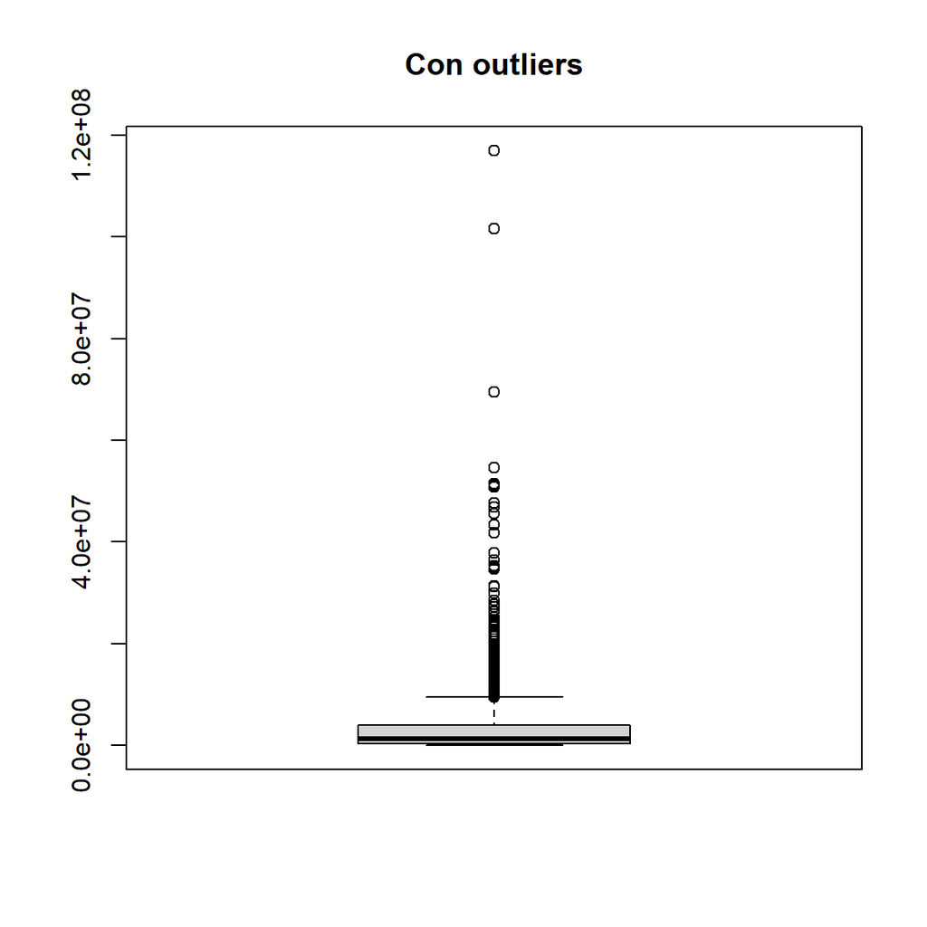

```r
boxplot(data$COSTO_ACTUALIZADO, main = "Con outliers")
```

Datos sin outliers

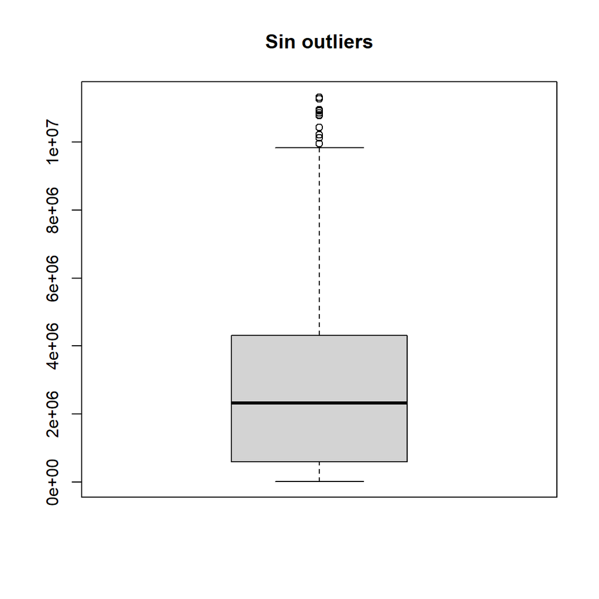

```r
boxplot(data_filtrada$COSTO_ACTUALIZADO, main = "Sin outliers")
```

En esta “data_filtrada” lo agrupo por distrito y provincia:

```r
library(dplyr)

data_filtrada <- data_filtrada %>%
  group_by(DISTRITO, PROVINCIA) %>%
  summarise(
    TOTAL_INVERSION = sum(COSTO_ACTUALIZADO, na.rm = TRUE)
  ) %>%
  arrange(desc(TOTAL_INVERSION))
```

Con esto tendría la data del monto de las inversiones realizadas desde el 2021 hasta el 2025.

### Pequeño revisión de las fechas

```r
proyectos_por_anio <- data %>%
  group_by(FECHA_REGISTRO) %>%
  summarise(
    CANTIDAD_PROYECTOS = n()
  ) %>%
  arrange(desc(FECHA_REGISTRO))
```

Pequeña revisión:

```r
library(knitr)
library(kableExtra)
kable(head(proyectos_por_anio, 10),
      caption = "Cantidad de proyectos por año (Top 10)") %>%
  kable_styling(bootstrap_options = c("striped", "hover", "condensed"), full_width = FALSE)
```

Cantidad de proyectos por año (Top 10)

| FECHA_REGISTRO | CANTIDAD_PROYECTOS |
| --- | --- |
| 2025 | 31 |
| 2024 | 363 |
| 2023 | 270 |
| 2022 | 77 |
| 2021 | 62 |
| 2020 | 77 |
| 2019 | 90 |
| 2018 | 48 |
| 2017 | 62 |
| 2016 | 108 |

Ahora hacemos un gráfico para visualizarlo mejor:

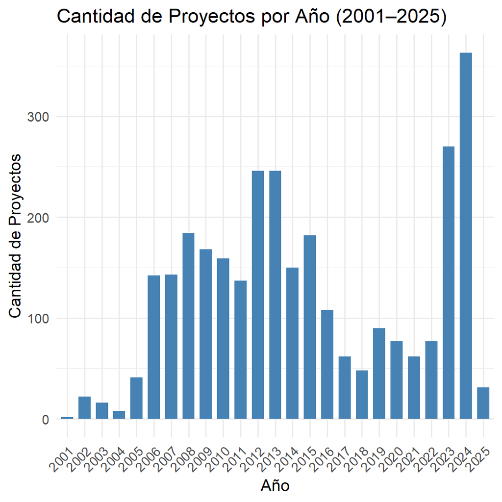

```r
library(ggplot2)
ggplot(proyectos_por_anio, aes(x = as.factor(FECHA_REGISTRO), y = CANTIDAD_PROYECTOS)) +
  geom_bar(stat = "identity", width = 0.7, fill = "steelblue") +
  labs(
    title = "Cantidad de Proyectos por Año (2001–2025)",
    x = "Año",
    y = "Cantidad de Proyectos"
  ) +
  theme_minimal(base_size = 14) +  # Aumenta el tamaño general del texto
  theme(axis.text.x = element_text(angle = 45, hjust = 1))  # Gira etiquetas del eje X
```

Se rescata que la mayor información se concentra por el 2024, mientras que en conjunto, la mayor distribución de inversiones estaría entre 2006 hasta el 2016.

## DATA DE DENSIDAD POBLACIONAL

Se encontraron dos bases de datos:

```r
library(rio)
data_estimacion <- import("estimacion_poblacion.xlsx") #Este refiere a la estimación de población de 2018 hasta el 2025
data_densidad <- import("censo_poblacion_2021.csv") #Este solo contiene información del 2021
```

### DATA DE DENSIDAD 2021

Filtración de la primera data sobre densidad sobre todo lo que tenga que ver con Ayacucho:

```r
data_densidad <- data_densidad %>%
  filter(Departamento == "AYACUCHO")
```

La data está dividida por sexo y edad, agrupamos todos esos datos para que solo hayan observaciones por distrito:

```r
data_densidad <- data_densidad %>%
  group_by(Distrito) %>%
  summarise(Cantidad = sum(Cantidad, na.rm = TRUE)) %>%
  arrange(desc(Cantidad))  #Ordena de mayor a menor
```

Cambiamos nombres de la data de densidad (para realizar merge):

```r
colnames(data_densidad)[1] <- "DISTRITO"
colnames(data_densidad)[2] <- "D_2021"
```

### DATA DE ESTIMACIÓN 2018-2025

Cambiamos nombres de la data de estimación:

```r
colnames(data_estimacion)[2] <- "Departamento"
colnames(data_estimacion)[3] <- "Provincia"
colnames(data_estimacion)[4] <- "Distrito"
```

Filtramos la data de estimación por el departamento:

```r
data_estimacion <- data_estimacion %>%
  filter(Departamento == "AYACUCHO")
```

Eliminamos columnas:

```r
data_estimacion <- data_estimacion %>%
  select(-...1, -Departamento, -Provincia, -INDICADOR, -UNIDAD_DE_MEDIDA)
```

Seguimos cambiando nombres de la data de estimación:

```r
colnames(data_estimacion)[1] <- "DISTRITO"
colnames(data_estimacion)[2] <- "D_2018"
colnames(data_estimacion)[3] <- "D_2019"
colnames(data_estimacion)[4] <- "D_2020"
colnames(data_estimacion)[5] <- "D_2021"
colnames(data_estimacion)[6] <- "D_2022"
colnames(data_estimacion)[7] <- "D_2023"
colnames(data_estimacion)[8] <- "D_2024"
colnames(data_estimacion)[9] <- "D_2025"
```

## MERGE

Unimos las bases de datos para realizar las pruebas:

```r
data_final <- left_join(data_filtrada, data_densidad, by = "DISTRITO")
```

Calculamos la inversión per cápita

```r
data_final <- data_final %>%
  mutate(INVERSION_PER_CAPITA = TOTAL_INVERSION / D_2021)
```

OJO aquí, el monto de inversión por distrito contiene la suma de todos los años, por lo que la inversión per cápita también está sumada. Si se quiere calcular la inversión per cápita por año, se debe dividir entre la cantidad de años (en este caso 5). Pero por temas de practicidad, se trabajará de la siguiente con esta suma de 5 años consecutivos (2021-2025)

# PRUEBAS

## INVERSIÓN PER CÁPITA

Anteriormente ya se calculó la inversión per cápita por lo que procedemos con el gráfico:

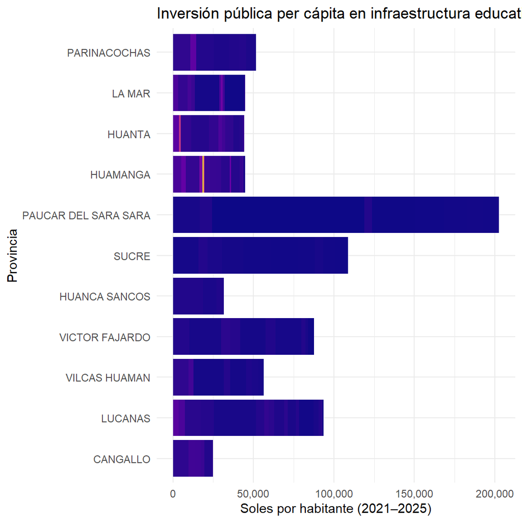

```r
library(ggplot2)
library(scales)   #para etiquetas con separadores de miles

ggplot(data_final,
       aes(x = reorder(PROVINCIA, INVERSION_PER_CAPITA),   #ordenar por inversión per cápita
           y = INVERSION_PER_CAPITA,
           fill = D_2021)) +
  geom_col(show.legend = FALSE) +
  coord_flip() +
  scale_y_continuous(labels = label_number(big.mark = ",")) +
  scale_fill_viridis_c(option = "plasma") +
  labs(title = "Inversión pública per cápita en infraestructura educativa",
       x = "Provincia",
       y = "Soles por habitante (2021–2025)") +
  theme_minimal()
```

## MATRIZ DE PROVINCIAS CRÍTICAS (ALTA/BAJA)

Con esto podremos ver la relación entre la inversión y la población. La idea es identificar provincias con alta inversión y baja población, o baja inversión y alta población:

```r
#Cálculo de umbrales (mediana)
med_inv  <- median(data_final$TOTAL_INVERSION,  na.rm = TRUE)
med_pob  <- median(data_final$D_2021,  na.rm = TRUE)
```

A partir de las medianas, podremos clasificar al total de inversión y la población por “Alta” o “Baja”:

```r
#Clasificación
matriz_crit <- data_final %>%
  mutate(
    CLASE_INVERSION  = ifelse(TOTAL_INVERSION   >= med_inv, "Alta", "Baja"),
    CLASE_POBLACION  = ifelse(D_2021   >= med_pob, "Alta", "Baja")
  ) %>%
  select(PROVINCIA, DISTRITO, CLASE_POBLACION, CLASE_INVERSION)
```

Ahora veremos los distritos con baja inversión y alta población:

```r
crit_altaP_bajaI <- matriz_crit %>%
  filter(CLASE_POBLACION == "Alta", CLASE_INVERSION == "Baja")
kable(crit_altaP_bajaI,
      caption = "Distritos con alta población y baja inversión") %>%
  kable_styling(bootstrap_options = c("striped", "hover", "condensed"), full_width = FALSE)
```

Distritos con alta población y baja inversión

| PROVINCIA | DISTRITO | CLASE_POBLACION | CLASE_INVERSION |
| --- | --- | --- | --- |
| LUCANAS | AUCARA | Alta | Baja |
| LUCANAS | LUCANAS | Alta | Baja |
| PARINACOCHAS | PACAPAUSA | Alta | Baja |
| HUANTA | LURICOCHA | Alta | Baja |
| HUANTA | SANTILLANA | Alta | Baja |
| VILCAS HUAMAN | CONCEPCION | Alta | Baja |
| HUAMANGA | ACOS VINCHOS | Alta | Baja |
| LUCANAS | CARMEN SALCEDO | Alta | Baja |
| HUANTA | IGUAIN | Alta | Baja |
| LA MAR | AYNA | Alta | Baja |
| HUANTA | AYAHUANCO | Alta | Baja |
| LA MAR | SAMUGARI | Alta | Baja |
| LUCANAS | OTOCA | Alta | Baja |
| HUAMANGA | SOCOS | Alta | Baja |
| CANGALLO | TOTOS | Alta | Baja |
| LA MAR | CHILCAS | Alta | Baja |
| LUCANAS | CABANA | Alta | Baja |

Vemos que son 17 distritos y que ya no se concentran en LUCANAS. Revisamos las frecuencias:

```r
table(crit_altaP_bajaI$PROVINCIA)
```

```
##
##      CANGALLO      HUAMANGA        HUANTA        LA MAR       LUCANAS
##             1             2             4             3             5
##  PARINACOCHAS VILCAS HUAMAN
##             1             1
```

Ahora vemos que LUCANAS sigue siendo el que tiene baja inversión pese a tener alta población. Le seguiría HUANTA y luego LA MAR.

Ahora procederemos con baja población & Alta inversión

```r
crit_bajaP_altaI <- matriz_crit %>%
  filter(CLASE_POBLACION == "Baja", CLASE_INVERSION == "Alta")
kable(crit_bajaP_altaI,
      caption = "Distritos con baja población y alta inversión") %>%
  kable_styling(bootstrap_options = c("striped", "hover", "condensed"), full_width = FALSE)
```

Distritos con baja población y alta inversión

| PROVINCIA | DISTRITO | CLASE_POBLACION | CLASE_INVERSION |
| --- | --- | --- | --- |
| HUANCA SANCOS | SANTIAGO DE LUCANAMARCA | Baja | Alta |
| PARINACOCHAS | UPAHUACHO | Baja | Alta |
| VICTOR FAJARDO | SARHUA | Baja | Alta |
| VICTOR FAJARDO | HUAMANQUIQUIA | Baja | Alta |
| LUCANAS | LEONCIO PRADO | Baja | Alta |
| PAUCAR DEL SARA SARA | OYOLO | Baja | Alta |
| PARINACOCHAS | PUYUSCA | Baja | Alta |
| PAUCAR DEL SARA SARA | LAMPA | Baja | Alta |
| VILCAS HUAMAN | ACCOMARCA | Baja | Alta |
| SUCRE | MORCOLLA | Baja | Alta |
| PAUCAR DEL SARA SARA | SAN JOSE DE USHUA | Baja | Alta |
| LA MAR | LUIS CARRANZA | Baja | Alta |
| PARINACOCHAS | CHUMPI | Baja | Alta |
| VICTOR FAJARDO | COLCA | Baja | Alta |
| SUCRE | QUEROBAMBA | Baja | Alta |
| VICTOR FAJARDO | ALCAMENCA | Baja | Alta |
| LUCANAS | SAN PEDRO DE PALCO | Baja | Alta |

Revisamos la cantidad de provincias:

```r
table(crit_bajaP_altaI$PROVINCIA)
```

```
##
##        HUANCA SANCOS               LA MAR              LUCANAS
##                    1                    1                    2
##         PARINACOCHAS PAUCAR DEL SARA SARA                SUCRE
##                    3                    3                    2
##       VICTOR FAJARDO        VILCAS HUAMAN
##                    4                    1
```

Contamos ahora con 17 distritos. La provincia de VICTOR FAJARDO tiene la mayor cantidad de distritos con baja población y alta inversión. Le seguiría PAUCAR DEL SARA SARA (lo que responde un poco la gran inversión vista en el primer gráfico sobre inversión per cápita) y PARINACOHAS.

Ahora revisamos los que tienen baja población y baja inversión:

```r
crit_bajaP_bajaI <- matriz_crit %>%
  filter(CLASE_POBLACION == "Baja", CLASE_INVERSION == "Baja")
kable(crit_bajaP_bajaI,
      caption = "Distritos con baja población y baja inversión") %>%
  kable_styling(bootstrap_options = c("striped", "hover", "condensed"), full_width = FALSE)
```

Distritos con baja población y baja inversión

| PROVINCIA | DISTRITO | CLASE_POBLACION | CLASE_INVERSION |
| --- | --- | --- | --- |
| SUCRE | SAN SALVADOR DE QUIJE | Baja | Baja |
| HUANCA SANCOS | SACSAMARCA | Baja | Baja |
| PAUCAR DEL SARA SARA | PAUSA | Baja | Baja |
| SUCRE | SAN PEDRO DE LARCAY | Baja | Baja |
| LUCANAS | SAN CRISTOBAL | Baja | Baja |
| PAUCAR DEL SARA SARA | CORCULLA | Baja | Baja |
| SUCRE | HUACAÑA | Baja | Baja |
| PARINACOCHAS | CORONEL CASTAÑEDA | Baja | Baja |
| CANGALLO | MARIA PARADO DE BELLIDO | Baja | Baja |
| HUANCA SANCOS | CARAPO | Baja | Baja |
| SUCRE | CHALCOS | Baja | Baja |
| VILCAS HUAMAN | CARHUANCA | Baja | Baja |
| PAUCAR DEL SARA SARA | SAN JAVIER DE ALPABAMBA | Baja | Baja |
| VICTOR FAJARDO | HUANCARAYLLA | Baja | Baja |
| PAUCAR DEL SARA SARA | PARARCA | Baja | Baja |
| HUANTA | CHACA | Baja | Baja |
| VICTOR FAJARDO | CAYARA | Baja | Baja |
| VILCAS HUAMAN | HUAMBALPA | Baja | Baja |
| PAUCAR DEL SARA SARA | MARCABAMBA | Baja | Baja |
| LUCANAS | SAN JUAN | Baja | Baja |
| SUCRE | SANTIAGO DE PAUCARAY | Baja | Baja |
| VICTOR FAJARDO | VILCANCHOS | Baja | Baja |
| SUCRE | SORAS | Baja | Baja |
| LA MAR | ORONCCOY | Baja | Baja |
| VILCAS HUAMAN | INDEPENDENCIA | Baja | Baja |
| LUCANAS | SANTA ANA DE HUAYCAHUACHO | Baja | Baja |
| PAUCAR DEL SARA SARA | SARA SARA | Baja | Baja |
| SUCRE | BELEN | Baja | Baja |
| SUCRE | CHILCAYOC | Baja | Baja |
| LUCANAS | LARAMATE | Baja | Baja |
| LUCANAS | HUAC-HUAS | Baja | Baja |
| VILCAS HUAMAN | SAURAMA | Baja | Baja |
| VICTOR FAJARDO | APONGO | Baja | Baja |
| PAUCAR DEL SARA SARA | COLTA | Baja | Baja |
| HUAMANGA | SANTIAGO DE PISCHA | Baja | Baja |
| VICTOR FAJARDO | ASQUIPATA | Baja | Baja |
| LUCANAS | LLAUTA | Baja | Baja |
| LUCANAS | SANTA LUCIA | Baja | Baja |
| LUCANAS | CHAVIÑA | Baja | Baja |

Miramos ahora las provincias:

```r
table(crit_bajaP_bajaI$PROVINCIA)
```

```
##
##             CANGALLO             HUAMANGA        HUANCA SANCOS
##                    1                    1                    2
##               HUANTA               LA MAR              LUCANAS
##                    1                    1                    8
##         PARINACOCHAS PAUCAR DEL SARA SARA                SUCRE
##                    1                    7                    8
##       VICTOR FAJARDO        VILCAS HUAMAN
##                    5                    4
```

## CORRELACION INVERSION VS POBLACIÓN

```r
cor_total <- cor(data_final$TOTAL_INVERSION,
                 data_final$D_2021,
                 use = "complete.obs")

cor_total
```

```
## [1] 0.3995037
```

Es probable que la asignación de estos outliers se deba a criterios estratégicos u otras prioridades distintas a la población.

## Ranking de eficiencia relativa

Ahora miremos un poco sobre aquellos distritos con gran eficiencia de gasto. Para esto, calculamos la eficiencia relativa de cada distrito como la inversión total dividida entre el logaritmo de la población del 2021:

```r
ranking_eff <- data_final %>%
  mutate(EFICIENCIA_RELATIVA = TOTAL_INVERSION / log(D_2021)) %>%
  arrange(desc(EFICIENCIA_RELATIVA))
```

Miramos el ranking de los mejores 10 distritos:

```r
kable(head(ranking_eff, 10),
      caption = "Ranking de los mejores 10 distritos") %>%
  kable_styling(bootstrap_options = c("striped", "hover", "condensed"), full_width = FALSE)
```

Ranking de los mejores 10 distritos

| DISTRITO | PROVINCIA | TOTAL_INVERSION | D_2021 | INVERSION_PER_CAPITA | EFICIENCIA_RELATIVA |
| --- | --- | --- | --- | --- | --- |
| PULLO | PARINACOCHAS | 55995745 | 5106 | 10966.656 | 6558283 |
| SANTIAGO DE LUCANAMARCA | HUANCA SANCOS | 51123435 | 2752 | 18576.830 | 6454911 |
| ACOCRO | HUAMANGA | 55524001 | 10644 | 5216.460 | 5987867 |
| SIVIA | HUANTA | 57120962 | 15068 | 3790.879 | 5937527 |
| CORACORA | PARINACOCHAS | 55577156 | 16050 | 3462.751 | 5739388 |
| TAMBILLO | HUAMANGA | 49510424 | 5964 | 8301.547 | 5695110 |
| VISCHONGO | VILCAS HUAMAN | 47098206 | 4902 | 9607.957 | 5542662 |
| PARAS | CANGALLO | 46242342 | 4775 | 9684.260 | 5458804 |
| PUQUIO | LUCANAS | 50985060 | 14414 | 3537.190 | 5324279 |
| VINCHOS | HUAMANGA | 50093463 | 17439 | 2872.496 | 5129130 |

Es cierto que Huamanga sigue estando presente, pero hay otros distritos que salen a la luz como PULLO que estaba en el 10mo lugar contra los outliers. ACOCRO se ha mantenido. SANTIAGO DE LUCANAMARCA aparece en la lista (antes no estaba). Al final los únicos que se mantuvieron fueron: ACOCRO, PULLO, CORACORA y PUQUIO.

Procedemos a mirar los peores 10 distritos:

```r
ranking_eff <- data_final %>%
  mutate(EFICIENCIA_RELATIVA = TOTAL_INVERSION / log(D_2021)) %>%
  arrange(EFICIENCIA_RELATIVA)     # orden ascendente = menos eficientes

worst_eff <- head(ranking_eff, 10) # 10 peores
kable(head(worst_eff, 10),
      caption = "Ranking de los peores 10 distritos") %>%
  kable_styling(bootstrap_options = c("striped", "hover", "condensed"), full_width = FALSE)
```

Ranking de los peores 10 distritos

| DISTRITO | PROVINCIA | TOTAL_INVERSION | D_2021 | INVERSION_PER_CAPITA | EFICIENCIA_RELATIVA |
| --- | --- | --- | --- | --- | --- |
| CHAVIÑA | LUCANAS | 49446.69 | 2106 | 23.47896 | 6461.469 |
| SANTA LUCIA | LUCANAS | 310178.02 | 954 | 325.13419 | 45211.081 |
| LLAUTA | LUCANAS | 620595.39 | 1193 | 520.19731 | 87602.422 |
| CABANA | LUCANAS | 1646017.82 | 4685 | 351.33785 | 194746.121 |
| SANTIAGO DE PISCHA | HUAMANGA | 1897193.94 | 1877 | 1010.75863 | 251703.025 |
| ASQUIPATA | VICTOR FAJARDO | 1590124.61 | 467 | 3404.97775 | 258711.264 |
| CHILCAS | LA MAR | 2164292.00 | 3193 | 677.82399 | 268232.510 |
| COLTA | PAUCAR DEL SARA SARA | 1971877.07 | 1188 | 1659.82918 | 278512.668 |
| APONGO | VICTOR FAJARDO | 2823367.56 | 1463 | 1929.84796 | 387386.510 |
| TOTOS | CANGALLO | 3706153.12 | 3880 | 955.19410 | 448491.869 |

No hay cambios.

# EXPORTAR RESULTADOS

Para no perder el progreso:

```r
writexl::write_xlsx(list(
  grafico_inversion = data_final,
  bajaP_altaI       = crit_bajaP_altaI,
  bajaP_bajaI       = crit_bajaP_bajaI,
  ranking_peores    = worst_eff
), "analisis_inversion_educativa.xlsx")
```